# data_preparation

**This Python code performs essential steps in preparing and preprocessing the Iris dataset for machine learning analysis. Each of these steps ensures that the dataset is properly cleaned, preprocessed, and ready for model training, which is critical for building reliable and accurate machine learning models.**

```python
import numpy as np
import pandas as pd

from sklearn.model_selection import train_test_split
from sklearn.preprocessing   import StandardScaler
from sklearn.datasets import load_iris

import matplotlib.pyplot as plt
import seaborn as sns
from mpl_toolkits.mplot3d import Axes3D
```

## Loading the Dataset:

**The Iris dataset is loaded using the load_iris() function, with data and target values extracted. The feature names are adjusted for readability (spaces replaced with underscores) to make them easier to reference in the following steps. The data is then stored in a Pandas DataFrame, which provides a tabular structure that makes data manipulation easier.**

```python
dataset = load_iris()
data = dataset.data
target = dataset.target
```

```python
cols = dataset.feature_names
cols = [x[:-5].replace(' ','_') for x in cols]
```

```python
df = pd.DataFrame(data=np.c_[data,target], columns=cols+['target'])
print(df)
df.info()
```

```
     sepal_length  sepal_width  petal_length  petal_width  target
0             5.1          3.5           1.4          0.2     0.0
1             4.9          3.0           1.4          0.2     0.0
2             4.7          3.2           1.3          0.2     0.0
3             4.6          3.1           1.5          0.2     0.0
4             5.0          3.6           1.4          0.2     0.0
..            ...          ...           ...          ...     ...
145           6.7          3.0           5.2          2.3     2.0
146           6.3          2.5           5.0          1.9     2.0
147           6.5          3.0           5.2          2.0     2.0
148           6.2          3.4           5.4          2.3     2.0
149           5.9          3.0           5.1          1.8     2.0

[150 rows x 5 columns]
<class 'pandas.core.frame.DataFrame'>
RangeIndex: 150 entries, 0 to 149
Data columns (total 5 columns):
 #   Column        Non-Null Count  Dtype
---  ------        --------------  -----
 0   sepal_length  150 non-null    float64
 1   sepal_width   150 non-null    float64
 2   petal_length  150 non-null    float64
 3   petal_width   150 non-null    float64
 4   target        150 non-null    float64
dtypes: float64(5)
memory usage: 6.0 KB
```

## Handling Duplicates:

**Duplicate rows, if any, are identified and removed using drop_duplicates(). Removing duplicates is crucial because they can introduce bias in the model training process, leading to inaccurate predictions.**

```python
df[df.duplicated()]
df.drop_duplicates(inplace=True)
df.info()
```

```
<class 'pandas.core.frame.DataFrame'>
Index: 149 entries, 0 to 149
Data columns (total 5 columns):
 #   Column        Non-Null Count  Dtype
---  ------        --------------  -----
 0   sepal_length  149 non-null    float64
 1   sepal_width   149 non-null    float64
 2   petal_length  149 non-null    float64
 3   petal_width   149 non-null    float64
 4   target        149 non-null    float64
dtypes: float64(5)
memory usage: 7.0 KB
```

## Checking for Missing Data:

**The code checks for missing values using df.isnull().sum(). Missing data can negatively impact model training, and understanding if and where data is missing allows for proper handling (e.g., imputation or removal).**

```python
df.isnull().sum()
```

```
sepal_length    0
sepal_width     0
petal_length    0
petal_width     0
target          0
dtype: int64
```

## Descriptive Statistics:

**The df.describe().T function displays summary statistics for each feature. This step is important for understanding the distribution of the data, including the range, mean, and variance, which are key for preprocessing tasks like scaling.**

```python
df.describe().T
```

|  | count | mean | std | min | 25% | 50% | 75% | max |
| --- | --- | --- | --- | --- | --- | --- | --- | --- |
| sepal_length | 149.0 | 5.843624 | 0.830851 | 4.3 | 5.1 | 5.8 | 6.4 | 7.9 |
| sepal_width | 149.0 | 3.059732 | 0.436342 | 2.0 | 2.8 | 3.0 | 3.3 | 4.4 |
| petal_length | 149.0 | 3.748993 | 1.767791 | 1.0 | 1.6 | 4.3 | 5.1 | 6.9 |
| petal_width | 149.0 | 1.194631 | 0.762622 | 0.1 | 0.3 | 1.3 | 1.8 | 2.5 |
| target | 149.0 | 0.993289 | 0.817847 | 0.0 | 0.0 | 1.0 | 2.0 | 2.0 |

## Correlation Matrix:

**The correlation matrix (corr) provides insights into the relationships between features. Features with high correlation may need to be addressed to prevent multicollinearity, which can affect model performance. "sepal_width" has the least correlation, implying it may be less significant in predicting the target.**

```python
corr = df.corr()
corr
```

|  | sepal_length | sepal_width | petal_length | petal_width | target |
| --- | --- | --- | --- | --- | --- |
| sepal_length | 1.000000 | -0.118129 | 0.873738 | 0.820620 | 0.786971 |
| sepal_width | -0.118129 | 1.000000 | -0.426028 | -0.362894 | -0.422987 |
| petal_length | 0.873738 | -0.426028 | 1.000000 | 0.962772 | 0.949402 |
| petal_width | 0.820620 | -0.362894 | 0.962772 | 1.000000 | 0.956514 |
| target | 0.786971 | -0.422987 | 0.949402 | 0.956514 | 1.000000 |

## Visualizing data is crucial in data science because it helps to:

- **Identify Patterns and Trends: Visualizations make it easier to spot patterns, relationships, and trends that might not be apparent in raw data.**
- **Communicate Insights: Graphs and charts are powerful tools to present complex data in a clear and understandable way for stakeholders, allowing for more effective decision-making.**
- **Detect Outliers and Anomalies: Visualizations can highlight unusual data points, helping in error detection or understanding rare phenomena.**
- **Simplify Complex Data: They condense large volumes of data into digestible visuals, making analysis quicker and more intuitive.**

**This plot helps visualize pairwise relationships between all the features (sepal_length, sepal_width, petal_length, petal_width) and how the species (target) are distributed across these relationships. It's a great way to observe separations between species.**

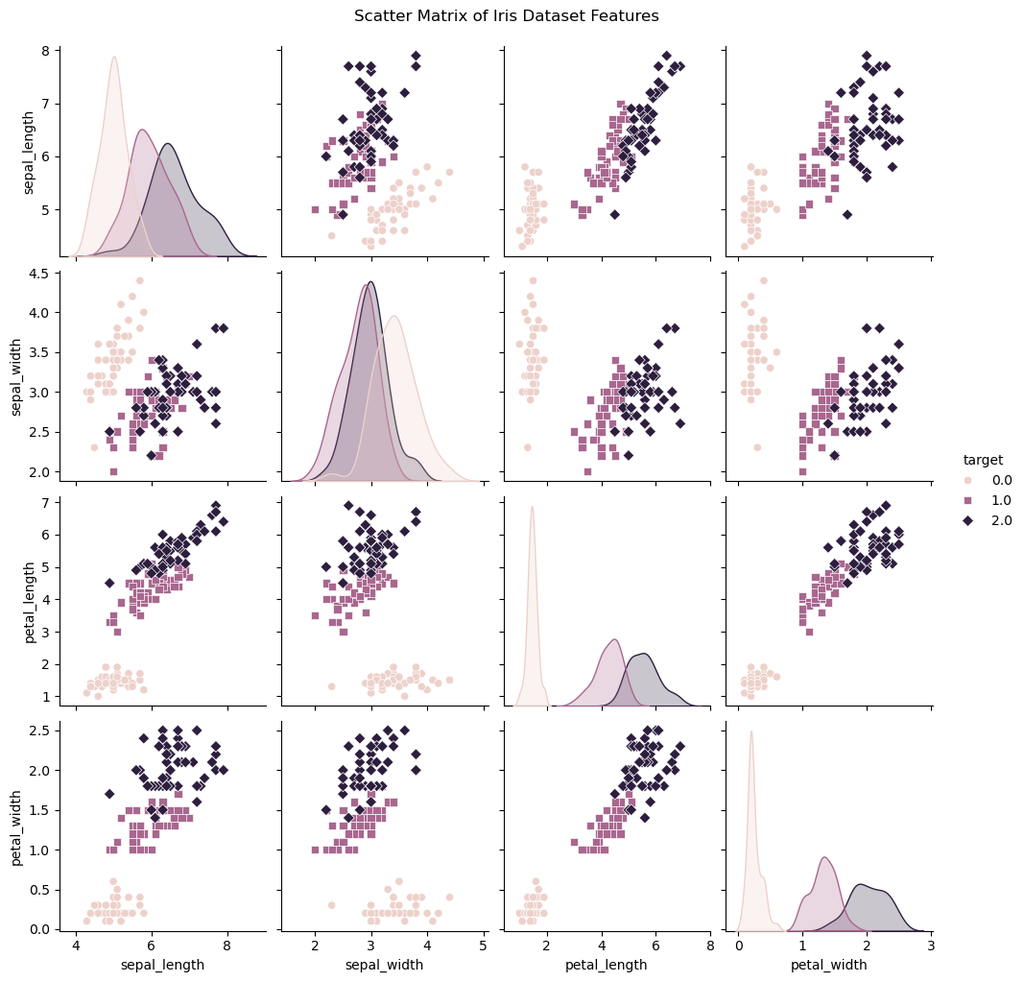

```python
sns.pairplot(df, hue='target', markers=["o", "s", "D"])
plt.suptitle("Scatter Matrix of Iris Dataset Features", y=1.02)
plt.show()
```

**A 3D scatter plot that displays petal_length, petal_width, and sepal_length for each species. This plot would allow us to see how the different species cluster in 3D space based on these features, showing how the Iris dataset's species can be linearly separated.**

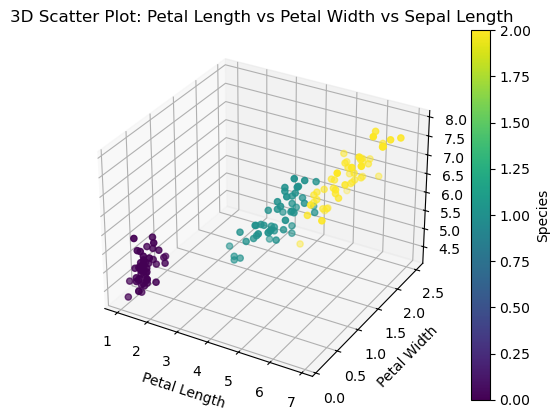

```python
fig = plt.figure()
ax = fig.add_subplot(111, projection='3d')
scatter = ax.scatter(df['petal_length'], df['petal_width'], df['sepal_length'], c=df['target'], cmap='viridis')
ax.set_xlabel('Petal Length')
ax.set_ylabel('Petal Width')
ax.set_zlabel('Sepal Length')
plt.title("3D Scatter Plot: Petal Length vs Petal Width vs Sepal Length")
plt.colorbar(scatter, label='Species')
plt.show()
```

**This plot shows the distribution of sepal_width across different species, including a box plot inside the violin to provide additional statistical insights:**

- Median: The white dot (or line) in the middle of the violin represents the median (50th percentile) of the data.
- Interquartile Range (IQR): The black bar shows the first quartile (25th percentile) to the third quartile (75th percentile), which represents the middle 50% of the data.
- Whiskers: The lines extending from the box (if present) show the range of the data excluding outliers (i.e., 1.5 times the IQR).
- A wide violin at a particular value indicates a high concentration of data points at that value. A narrow violin suggests that fewer data points exist in that range.

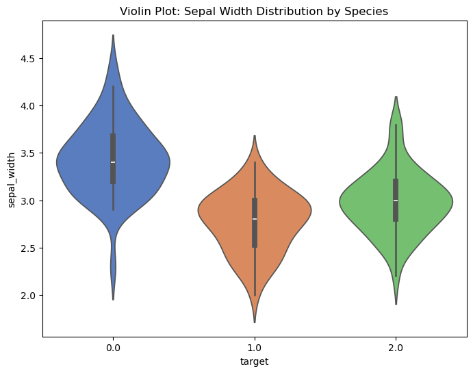

```python
plt.figure(figsize=(8, 6))
sns.violinplot(x='target', y='sepal_width', data=df, inner='box', palette='muted', hue='target', legend=False)
plt.title("Violin Plot: Sepal Width Distribution by Species")
plt.show()
```

## Feature Scaling:

**The features are scaled using StandardScaler. Scaling is crucial because many machine learning models perform better when features are on the same scale. It ensures that no single feature dominates the training process, improving the model's efficiency and accuracy.**

```python
X = df.copy()
y = X.pop('target')

X.head()
y.head()

scaler = StandardScaler()
scaler.fit(X)
X = scaler.transform(X)
```

## Train-Test Split:

**The dataset is split into training and testing sets using train_test_split(), with 80% used for training and 20% for testing. This split is important to evaluate the model's generalization to unseen data. A proper split prevents overfitting and allows for performance evaluation on new data.**

```python
X_train, X_test, y_train, y_test = train_test_split(X,y,test_size=0.2)
```